# Titanic Sruvivor Rate

## Data Dictionary

survival - 0=no, 1=yes pclass - 1=1st, 2=2nd, 3=3rd age - age in years sibsp - # of siblings / spouses aboard the Titanic parch - # of parents / children aboard the Titanic  
ticket - Ticket number  
fare - Passenger fare  
cabin - Cabin number  
embarked - Port of Embarkation C = Cherbourg, Q = Queenstown, S = Southampton

```
  PassengerId       Survived          Pclass          Name               Sex                 Age
 Min.   :  1.0   Min.   :0.0000   Min.   :1.000   Length:891         Length:891         Min.   : 0.42
 1st Qu.:223.5   1st Qu.:0.0000   1st Qu.:2.000   Class :character   Class :character   1st Qu.:20.12
 Median :446.0   Median :0.0000   Median :3.000   Mode  :character   Mode  :character   Median :28.00
 Mean   :446.0   Mean   :0.3838   Mean   :2.309                                         Mean   :29.70
 3rd Qu.:668.5   3rd Qu.:1.0000   3rd Qu.:3.000                                         3rd Qu.:38.00
 Max.   :891.0   Max.   :1.0000   Max.   :3.000                                         Max.   :80.00
                                                                                        NA's   :177
     SibSp           Parch           Ticket               Fare           Cabin             Embarked
 Min.   :0.000   Min.   :0.0000   Length:891         Min.   :  0.00   Length:891         Length:891
 1st Qu.:0.000   1st Qu.:0.0000   Class :character   1st Qu.:  7.91   Class :character   Class :character
 Median :0.000   Median :0.0000   Mode  :character   Median : 14.45   Mode  :character   Mode  :character
 Mean   :0.523   Mean   :0.3816                      Mean   : 32.20
 3rd Qu.:1.000   3rd Qu.:0.0000                      3rd Qu.: 31.00
 Max.   :8.000   Max.   :6.0000                      Max.   :512.33
```

###Missing Values in Dataset

First I would like to see which columns have missing values.

```r
sapply(all, function(x) {sum(is.na(x))})

missing_values <- all %>% summarize_all(funs(sum(is.na(.))/n()))


missing_values <- gather(missing_values, key="feature", value="missing_pct")

missing_values %>%

  ggplot(aes(x=reorder(feature,-missing_pct),y=missing_pct)) +

  geom_bar(stat="identity",fill="red")+

  coord_flip()+theme_bw()
```

[output not shown]

###Exploring some of the most important variables

Let’s explore which variables are the most important variables.

First, the survivor rate, our response variable.

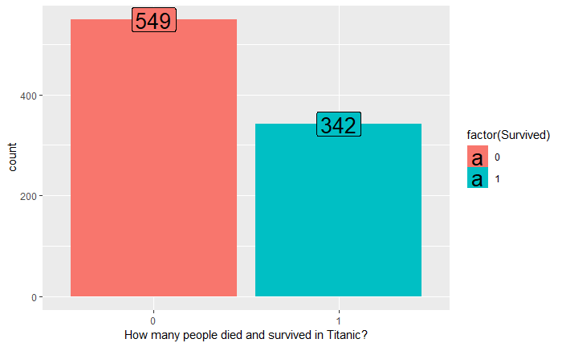

```r
ggplot(all[!is.na(all$Survived),], aes(Survived, fill=factor(Survived))) + geom_bar(stat="count") +
  labs(x="How many people died and survived in Titanic?") +
  geom_label(stat='count',aes(label=..count..), size=7)
```

Second, passenger class.

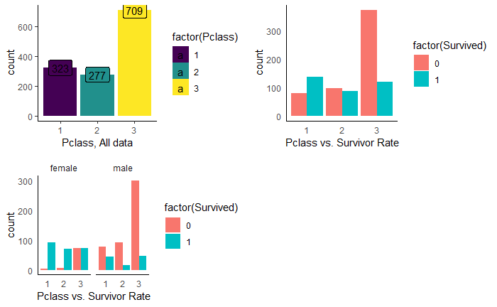

```r
p1 <- ggplot(all, aes(Pclass, fill=factor(Pclass))) +
  geom_bar(stat="count", position="dodge") +
  labs(x="Pclass, All data") +
  geom_label(stat='count', aes(label=..count..)) +
  theme_minimal() +
  theme_bw() +
  theme(panel.border = element_blank(), panel.grid.major = element_blank(),
        panel.grid.minor = element_blank(), axis.line = element_line(colour = "black"))

p2 <- ggplot(all[!is.na(all$Survived),], aes(Pclass, fill=factor(Survived))) +
  geom_bar(stat="count", position = "dodge") +
  labs(x="Pclass vs. Survivor Rate") +
  theme_minimal() +
  theme(panel.border = element_blank(), panel.grid.major = element_blank(),
        panel.grid.minor = element_blank(), axis.line = element_line(colour = "black"))

p3 <- ggplot(all[!is.na(all$Survived),], aes(Pclass, fill=factor(Survived))) +
  geom_bar(stat="count", position = "dodge") +
  labs(x="Pclass vs. Survivor Rate") +
  facet_grid(.~Sex) +
  theme_minimal() +
  theme(panel.border = element_blank(), panel.grid.major = element_blank(),
        panel.grid.minor = element_blank(), axis.line = element_line(colour = "black"))

grid.arrange(p1, p2, p3, ncol=2)
```

```r
p4 <- ggplot(all[!is.na(all$Survived),], aes(Sex, fill=factor(Survived))) +
  geom_bar(stat = "count", position="dodge") +
  geom_label(stat='count', aes(label=..count..))

p5 <-ggplot()
```

Fourth, survivor rate with age

```r
ggplot(all[!is.na(all$Survived),], aes(Age, fill=factor(Survived))) +
  geom_freqpoly(binwidth = 1, color = "blue") +
  geom_histogram(binwidth = 1, color = "red", alpha = .5) +
  theme_linedraw() +
  scale_y_continuous(limits = c(0, 40), breaks = c(0,20,40,60,80))
```

[output not shown]

Sibsp vs. Survivor

```r
ggplot(all[!is.na(all$Survived),], aes(SibSp, fill=factor(Survived))) +
  geom_bar(stat="count")
```

[output not shown]

Parch vs. Survivor

```r
ggplot(all[!is.na(all$Survived),], aes(Parch, fill=factor(Survived))) +
  geom_bar(stat="count")
```

[output not shown]

Fare vs. Survivor

```r
ggplot(all[!is.na(all$Survived),], aes(Fare,fill=factor(Survived))) +
  geom_density()
```

[output not shown]

I think that the most important variables are passenger class, gender, and survivor rate.

```r
all$Sex <- as.factor(all$Sex)
all$Survived <- as.factor(all$Survived)
all$Pclass <- as.ordered(all$Pclass)
```

## Featuring Engineering

### Creating the Title variable

```r
#Extracting title and surname from names
all$Surname <- sapply(all$Name, function(x) {strsplit(x, split='[,.]')[[1]][1]})
#correcting some surnames that also include a maiden name
all$Surname <- sapply(all$Surname, function(x) {strsplit(x, split='[-]')[[1]][1]})
all$Title <- sapply(all$Name, function(x) {strsplit(x, split='[,.]')[[1]][2]})
all$Title <- sub(' ', '', all$Title) #removing spaces before title
kable(table(all$Sex, all$Title))
```

[output not shown]

##Fixing mis spelled titles

```r
all$Title[all$Title %in% c("Mlle", "Ms")] <- "Miss"
all$Title[all$Title == "Mme"] <- "Mrs"
all$Title[!(all$Title %in% c('Master', 'Miss', 'Mr', 'Mrs'))] <- "Rare Title"
all$Title <- as.factor(all$Title)
kable(table(all$Sex, all$Title))
```

[output not shown]

```r
ggplot(all[!is.na(all$Survived),], aes(Title, fill=Survived)) +
  geom_bar(stat="count", position="stack") +
  labs(x="Title")
```

[output not shown]

### Finding groups of people traveling together

```r
all$FSize <- all$SibSp + all$Parch + 1
```

```r
ggplot(all[!is.na(all$Survived),], aes(FSize, fill=Survived)) +
  geom_bar(stat="count", position="dodge") +
   scale_x_continuous(breaks=c(1:11)) +
  labs(x = 'Family Size') + theme_minimal()
```

[output not shown]